# CS5801 Coursework Template Proforma

2027461

05 January, 2021

```r
#install.packages("ggplot2")
#install.packages("dplyr")
#install.packages("stringr")
#install.packages("naniar")
#install.packages("validate")
#install.packages("purrr")
#install.packages("gridExtra")
#install.packages("tidyr")
```

```r
#ggplot library for visualization
library(ggplot2)
#dplyr library for data manipulation
library(dplyr)
#stringr library is for string manipulation
library(stringr)
#naniar library is for visualising missing data
library(naniar)
#validate library for data validation
library(validate)
library(purrr)
#grid Extra for plotting multiple plot in grid
library(gridExtra)
library(tidyr)
```

# 1. Organise and clean the data

## 1.1 Subset the data into the specific dataset allocated

```r
#load data from local pc
load("CS5801_data.rda")

#load data direct from github
#load(url("https://raw.githubusercontent.com/mjshepperd/CS5702-Data/master/CS5801_data.rda"))
subdata.df <- subset(CS5801.data, teamID.x=="LAA"| teamID.x=="TEX")

#To arrange the row number
rownames(subdata.df) <- NULL
head(subdata.df)
```

|  | playerID | teamID.x | G | R | H | AB | RBI | weight | height | salary | birthDate | career.length | bats | age | hit.ind |
| --- | --- | --- | --- | --- | --- | --- | --- | --- | --- | --- | --- | --- | --- | --- | --- |
| 1 | alvarjo02 | LAA | 64 | 0 | 0 | 0 | 0 | 180 | 71 | 509500 | 1989-05-06 | 1.563313 | L | 25.65640 | 0 |
| 2 | andruel01 | TEX | 160 | 69 | 154 | 596 | 62 | 200 | 72 | 15000000 | 1988-08-26 | 5.738535 | R | 26.34908 | 1 |
| 3 | aybarer01 | LAA | 156 | 74 | 161 | 597 | 44 | 195 | 70 | 8500000 | 1984-01-14 | 8.629706 | B | 30.96509 | 1 |
| 4 | bassan01 | TEX | 33 | 0 | 0 | 0 | 0 | 200 | 74 | 725000 | 1987-11-01 | 3.553730 | R | 27.16769 | 0 |
| 5 | beltrad01 | TEX | 143 | 83 | 163 | 567 | 83 | 220 | 71 | 16000000 | 1979-04-07 | 16.522930 | R | 35.73717 | 1 |
| 6 | buterdr01 | LAA | 10 | 3 | 4 | 21 | 0 | 205 | 73 | 987500 | 1983-08-09 | 4.731006 | R | 31.39767 | 1 |

```r
dim(subdata.df)
```

```
## [1] 80 15
```

It has 80 rows and 15 columns

## 1.2 Data quality analysis

### Data Quality Analysis Plan

- First I will check if there any missing value
- Player ID should be unique
- TeamID Should not be more than three letter, and cannot be any value rather than LAA and TEX
- G(number of games), R(Runs), H(Hits), AB , RBI(Runs Batted in) cannot be negative
- Weight and Height cannot be negative, zero or any unreal value
- Salary cannot be negative or zero
- Career length cannot be more than a Player’s age. Can’t be zero or negative
- Hit.ind cant be any value rather tan 0 and 1

### Implementation

##### Check if there is any null value

```r
#To check if there any null value
is.null(subdata.df)
```

```
## [1] FALSE
```

##### Lets visualize it

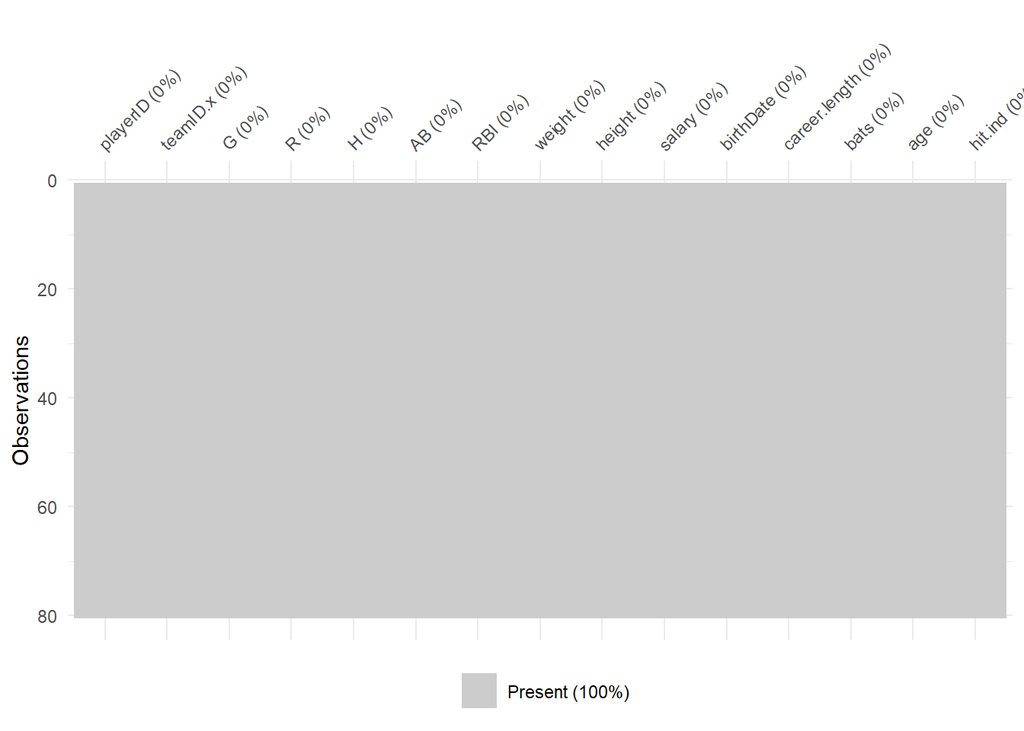

```r
vis_miss(subdata.df)
```

##### Check if there any duplicates in player ID

```r
#Lets see how much row we have
dim(subdata.df)[1]
```

```
## [1] 80
```

```r
#Lets see how much unique row we have
length(unique(subdata.df$playerID))
```

```
## [1] 78
```

There are two duplicate value Our data has 80 row and here we have unique 78 rows

##### Lets check the data quality

```r
data.rules <- validator(# hit.ind should be only zero and 1
                        hit_Ok = is.element(hit.ind, c(0,1)),
                        # team id only have two value, each with length of 3
                        team_Ok = is.element(teamID.x, c("LAA", "TEX")),
                        # left right or both handed
                        bats_Ok = is.element(bats, c("L", "B", "R")),
                        #gmes, runs, hits, Ab, rbi cant be negative
                        game_OK = G>=0,
                        runs_OK = R>=0,
                        hits_Ok = H>=0,
                        AB_Ok = AB>=0,
                        RBI_Ok = RBI>=0,
                        #weight should be positive and 350 pounds weighted person is obease
                        weight_Ok = weight>=0& weight<350,
                        #height should be positive and cant be more than 180 inch
                        height_Ok = height>=0 & height<108,
                        #players salary should be more than zer0
                        salary_Ok = salary>0,
                        #career lenght cant be greater than someones age
                        career_Ok = career.length>=0 & age>career.length,
                        #player cannt be too young or too old to play in a national team
                        age_Ok = age>=15 & age<=50
                        )

#comparing the rules with dataset
qual.check <- confront(subdata.df, data.rules)
summary(qual.check)
```

| name | items | passes | fails | nNA | error | warning | expression |
| --- | --- | --- | --- | --- | --- | --- | --- |
| hit_Ok | 80 | 80 | 0 | 0 | FALSE | FALSE | is.element(hit.ind, c(0, 1)) |
| team_Ok | 80 | 80 | 0 | 0 | FALSE | FALSE | is.element(teamID.x, c("LAA", "TEX")) |
| bats_Ok | 80 | 80 | 0 | 0 | FALSE | FALSE | is.element(bats, c("L", "B", "R")) |
| game_OK | 80 | 80 | 0 | 0 | FALSE | FALSE | (G - 0) >= -1e-08 |
| runs_OK | 80 | 80 | 0 | 0 | FALSE | FALSE | (R - 0) >= -1e-08 |
| hits_Ok | 80 | 80 | 0 | 0 | FALSE | FALSE | (H - 0) >= -1e-08 |
| AB_Ok | 80 | 80 | 0 | 0 | FALSE | FALSE | (AB - 0) >= -1e-08 |
| RBI_Ok | 80 | 79 | 1 | 0 | FALSE | FALSE | (RBI - 0) >= -1e-08 |
| weight_Ok | 80 | 79 | 1 | 0 | FALSE | FALSE | weight >= 0 & weight < 350 |
| height_Ok | 80 | 80 | 0 | 0 | FALSE | FALSE | height >= 0 & height < 108 |

[output cut: 3 more lines]

##### Let us summarise our findings of the quality issue

- There is no null value in the dataset
- we have 2 duplicates in our player id.
- We can see that there is some anomaly in Runs Bated IN (RBI) column. In has one negative value
- There is some anomaly in a row in where weight is unnatural
- In career column a value where career length is greater than someones age

Let us visualize our data quality

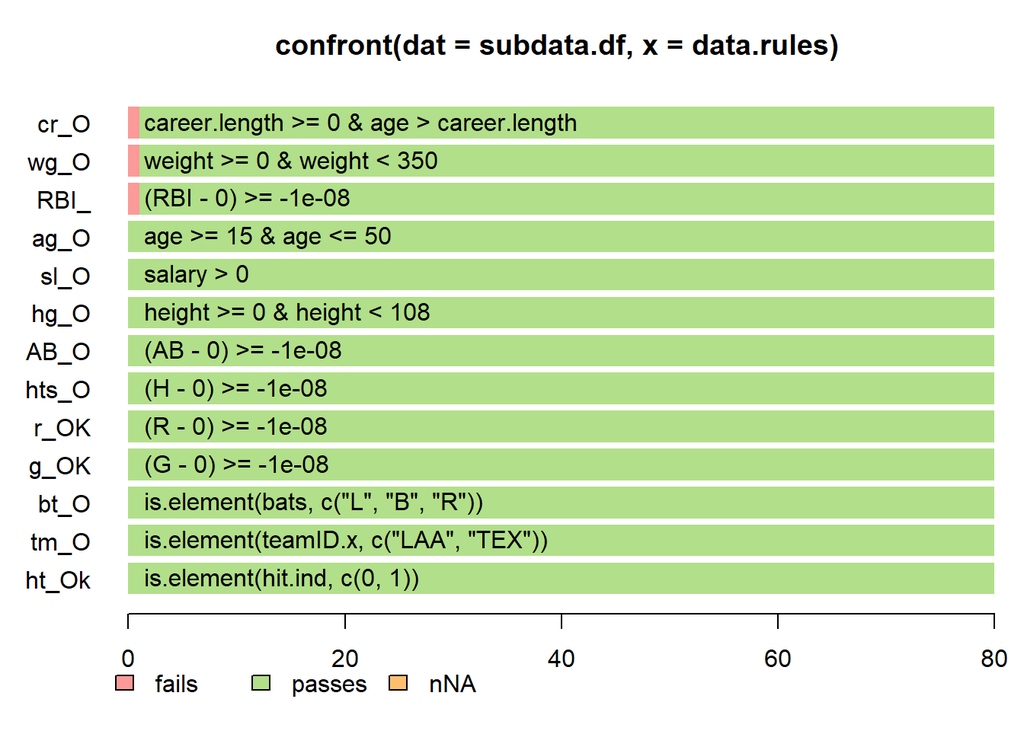

```r
barplot(qual.check, xlab = "")
```

## 1.3 Data cleaning

### Implementing data cleaning

Lets find which value are duplicated in the player id

```r
duplicate <- subdata.df$playerID[duplicated(subdata.df$playerID)]
duplicate
```

```
## [1] "richaga01" "lewisco01"
```

Now lets find in which rows the value lies

```r
for (val in duplicate)
{
  cat(val, "appeared in row number: ",  which(subdata.df$playerID == val, arr.ind=TRUE), "\n")
  #cat function concatinate the strings and values
  #which function search for the duplicate value in the player ID
}
```

```
## richaga01 appeared in row number:  50 71
## lewisco01 appeared in row number:  34 76
```

So we can see richga01 appears in row 50 and also in row 71 lewisc01 occurs in row number 34 and 76

Lets see if all the contents of duplicated rows are same or not

```r
ifelse(subdata.df[50, ] == subdata.df[71, ], "Matched", "Mismatched")
```

```
##    playerID  teamID.x  G         R         H         AB        RBI
## 50 "Matched" "Matched" "Matched" "Matched" "Matched" "Matched" "Matched"
##    weight    height    salary    birthDate career.length bats      age
## 50 "Matched" "Matched" "Matched" "Matched" "Mismatched"  "Matched" "Mismatched"
##    hit.ind
## 50 "Matched"
```

```r
ifelse(subdata.df[34, ] == subdata.df[76, ], "Matched", "Mismatched")
```

```
##    playerID  teamID.x  G         R         H         AB        RBI
## 34 "Matched" "Matched" "Matched" "Matched" "Matched" "Matched" "Matched"
##    weight    height    salary    birthDate career.length bats      age
## 34 "Matched" "Matched" "Matched" "Matched" "Mismatched"  "Matched" "Mismatched"
##    hit.ind
## 34 "Matched"
```

We can see maximum number of values of these two duplicates matched. So Lets Delete one copy of duplicates

```r
uni_sub <- subdata.df[-c(50, 34), ]

#we deleted duplicate row number 50 and 34
#uni_sub states for unique subdata
#Now lets rearrange row numbers again
rownames(uni_sub) <- NULL
```

Now lets check for negative values

```r
#Filtering the negative value containing rows
uni_sub %>%
  filter(G<0 | R<0 | H<0 | RBI<0 | weight<0 | height<0 | salary<0 | career.length<0 | age<0 | hit.ind<0)
```

| playerID | teamID.x | G | R | H | AB | RBI | weight | height | salary | birthDate | career.length | bats | age | hit.ind |
| --- | --- | --- | --- | --- | --- | --- | --- | --- | --- | --- | --- | --- | --- | --- |
| perezjj03 | TEX | 70 | 30 | 42 | 184 | -21 | 220 | 71 | 508600 | 1988-12-23 | 0.4791239 | R | 26.02327 | 1 |

Lets find the row number of that Id

```r
cat("The row number where negative value appears is: ", which(uni_sub$playerID == "perezjj03", arr.ind=TRUE))
```

```
## The row number where negative value appears is:  77
```

```r
#As this is the only row containing negative number we can remove it. But before that lets inspect the row very closely
uni_sub[77, ]
```

|  | playerID | teamID.x | G | R | H | AB | RBI | weight | height | salary | birthDate | career.length | bats | age | hit.ind |
| --- | --- | --- | --- | --- | --- | --- | --- | --- | --- | --- | --- | --- | --- | --- | --- |
| 77 | perezjj03 | TEX | 70 | 30 | 42 | 184 | -21 | 220 | 71 | 508600 | 1988-12-23 | 0.4791239 | R | 26.02327 | 1 |

We found in RBI column it have some negative value. Otherwise everything seems okay. And we assume that the negative mark putted unintentionally. As we deal with small dataset lets not remove it, rather than convert negative value to positive.

```r
uni_sub[77, ]$RBI<- uni_sub[77, ]$RBI * -1
```

Now lets deal wirh some players carrear length, greater than his age

```r
#Career length cannot be greater than  a players age

for(val in seq(1, dim(uni_sub)[1])){
  a <- (uni_sub$age[val]<uni_sub$career.length[val])

  if(isTRUE(a)){
   cat("Row number : ", val, ", contains career length greater than his/her age")
  }
}
```

```
## Row number :  72 , contains career length greater than his/her age
```

```r
uni_sub[72, ]
```

|  | playerID | teamID.x | G | R | H | AB | RBI | weight | height | salary | birthDate | career.length | bats | age | hit.ind |
| --- | --- | --- | --- | --- | --- | --- | --- | --- | --- | --- | --- | --- | --- | --- | --- |
| 72 | felizbg01 | LAA | 30 | 0 | 0 | 0 | 0 | 235 | 75 | 4125000 | 1988-05-02 | 35.41273 | R | 26.66667 | 0 |

we can remove this value. But we cannot afford this loss as our dataset contains only 78 values. So lets impute mean value to career length

```r
uni_sub[72, ]$career.length <- mean(uni_sub$career.length)
```

# 2. Exploratory Data Analysis (EDA)

## 2.1 EDA plan

##### Univariate Analysis

- Look at the histogram of numeric data to see if they are normally distributed
- Explore it numerically by doing shapiro test
- Look at the count of player left right or both handed (bar graph)

##### Bivariate Analysis

- To see if salary increase in terms of career length
- If there any multicoliniarity between age and career length
- which team have high salary

##### Multivariate Analysis

- To see Bargraph of Left right and BOth handed players in differet teams
- Hit. ind in different teams

## 2.2 EDA and summary of results

##### Univariate Analysis

First, Lets see if the numeric data are normally distributed by plotting histogram

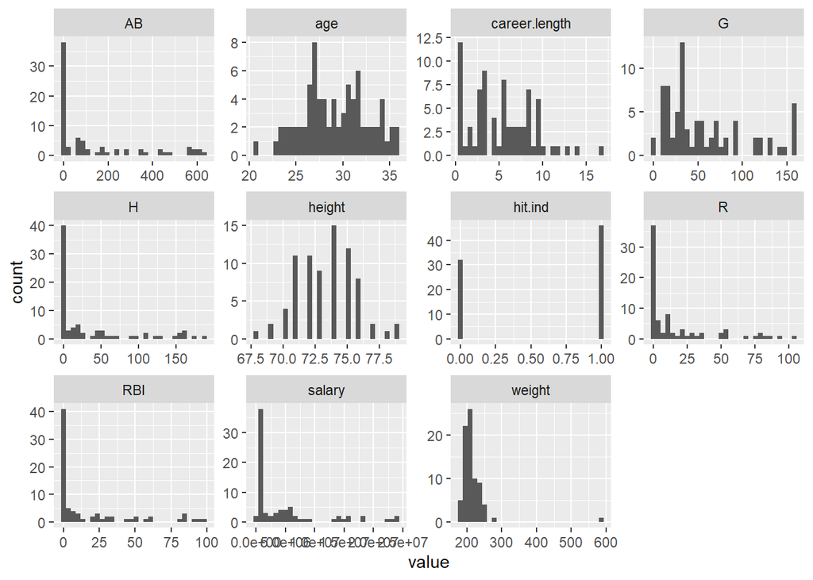

```r
uni_sub %>%
  keep(is.numeric) %>%
  gather() %>%
  ggplot(aes(value)) +
    facet_wrap(~ key, scales = "free") +
    geom_histogram()
```

Lets do shapiro test to see which column is normally distributed

```r
vis_column<- c("G", "R", "H", "AB", "RBI", "height", "weight", "salary", "age", "career.length" )
for (val in seq(1:10)){
  cat("Shapiro test for normality for column: ", vis_column[val])
  print(shapiro.test(get(vis_column[val], uni_sub)))
}
```

```
## Shapiro test for normality for column:  G
##  Shapiro-Wilk normality test
##
## data:  get(vis_column[val], uni_sub)
## W = 0.86172, p-value = 5.346e-07
##
## Shapiro test for normality for column:  R
##  Shapiro-Wilk normality test
##
## data:  get(vis_column[val], uni_sub)
## W = 0.69225, p-value = 1.692e-11
##
## Shapiro test for normality for column:  H
##  Shapiro-Wilk normality test
##
## data:  get(vis_column[val], uni_sub)
## W = 0.6896, p-value = 1.49e-11
##
## Shapiro test for normality for column:  AB
##  Shapiro-Wilk normality test
##
## data:  get(vis_column[val], uni_sub)
## W = 0.71235, p-value = 4.556e-11
##
## Shapiro test for normality for column:  RBI
##  Shapiro-Wilk normality test
##
## data:  get(vis_column[val], uni_sub)
## W = 0.67658, p-value = 8.058e-12
##
## Shapiro test for normality for column:  height
##  Shapiro-Wilk normality test
##
## data:  get(vis_column[val], uni_sub)
## W = 0.97633, p-value = 0.1547
##
## Shapiro test for normality for column:  weight
##  Shapiro-Wilk normality test
##
## data:  get(vis_column[val], uni_sub)
## W = 0.41872, p-value = 5.276e-16
##
## Shapiro test for normality for column:  salary
##  Shapiro-Wilk normality test
##
## data:  get(vis_column[val], uni_sub)
## W = 0.70249, p-value = 2.786e-11
##
## Shapiro test for normality for column:  age
##  Shapiro-Wilk normality test
##
## data:  get(vis_column[val], uni_sub)
## W = 0.98424, p-value = 0.4494
##
## Shapiro test for normality for column:  career.length
##  Shapiro-Wilk normality test
##
## data:  get(vis_column[val], uni_sub)
## W = 0.95373, p-value = 0.006513
```

Plot bar graph to see the proportion of left, right and both handed player And proportion of hit.ind

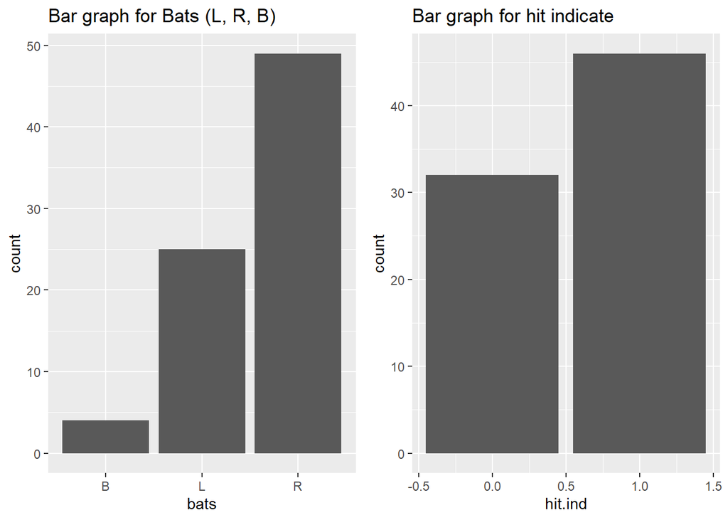

```r
par(mfrow = c(2, 2))
plt1 <- ggplot(data = uni_sub, aes(x= bats)) +geom_bar() + labs(title = "Bar graph for Bats (L, R, B)")
plt2 <- ggplot(data = uni_sub, aes(x= hit.ind)) +geom_bar() + labs(title = "Bar graph for hit indicate")
grid.arrange(plt1, plt2, ncol =2)
```

..

###### We see most of the players are Right handed. and more than 50 percent of them have made atleast one hit in 2015 season.

##### Bivariate Analysis

lets see if there any relation between career length vs salary

```r
cor(uni_sub$career.length, uni_sub$salary)
```

```
## [1] 0.6236861
```

we see the relation is not that much. Lets see how much we can trust the correation score

```r
cor.test(uni_sub$career.length, uni_sub$salary)
```

```
##
##  Pearson's product-moment correlation
##
## data:  uni_sub$career.length and uni_sub$salary
## t = 6.9558, df = 76, p-value = 1.064e-09
## alternative hypothesis: true correlation is not equal to 0
## 95 percent confidence interval:
##  0.4658039 0.7430846
## sample estimates:
##       cor
## 0.6236861
```

Here p value is very less. so we can trust the correation score.

Now lets visualizet the relation

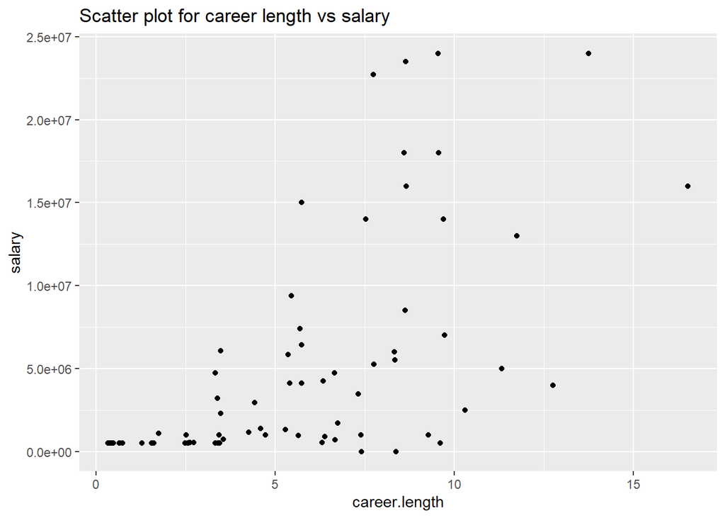

```r
ggplot(data = uni_sub, aes(x = career.length, y = salary)) + geom_point() + labs(title = "Scatter plot for career length vs salary")
```

..

we see there is some relation between career.length and salary. But the data followint heteroskadacity(change of variance over time) . In future if we want to do analysis with this relation, we have to deal with this.

We assume as age increases the carrear length also can be increased. lets see if there any multicollinarity between them. It will help us for further analysis

```r
summary(lm(career.length~age, data=uni_sub))
```

```
##
## Call:
## lm(formula = career.length ~ age, data = uni_sub)
##
## Residuals:
##     Min      1Q  Median      3Q     Max
## -7.9017 -1.2705 -0.2378  1.6458  7.8659
##
## Coefficients:
##              Estimate Std. Error t value Pr(>|t|)
## (Intercept) -18.49910    2.20137  -8.403 1.86e-12 ***
## age           0.81727    0.07487  10.915  < 2e-16 ***
## ---
## Signif. codes:  0 '***' 0.001 '**' 0.01 '*' 0.05 '.' 0.1 ' ' 1
##
## Residual standard error: 2.274 on 76 degrees of freedom
## Multiple R-squared:  0.6105, Adjusted R-squared:  0.6054
## F-statistic: 119.1 on 1 and 76 DF,  p-value: < 2.2e-16
```

we can see that there is a significant relation between age and career length. R squared is 0.60, that is our model can explain 61 percent of its variables. F statistics is also significant.

Lets visualize it

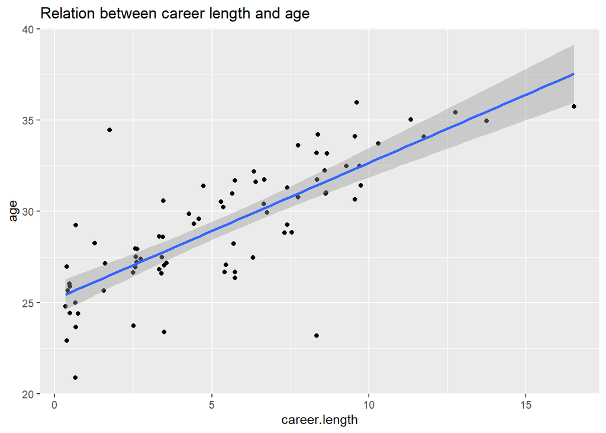

```r
ggplot(data = uni_sub, aes(career.length, age))+geom_point()+geom_smooth(method = lm)+labs(title = "Relation between career length and age")
```

..

Now lets see boxplot for salary for both the team

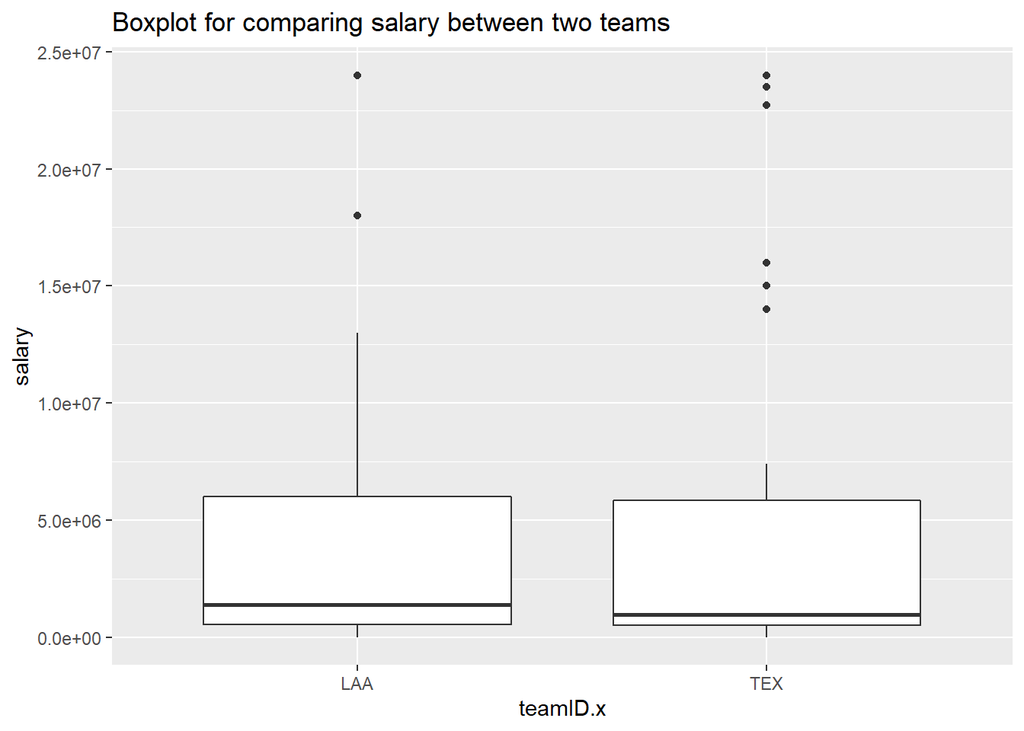

```r
ggplot(data = uni_sub, aes(x = teamID.x, y = salary)) + geom_boxplot()+labs(title = "Boxplot for comparing salary between two teams")
```

..

we see there is not that much difference between salary betweent the two teams. Lets do some hypothesis testing.

```r
summary(aov(uni_sub$salary~uni_sub$teamID.x))
```

```
##                  Df    Sum Sq   Mean Sq F value Pr(>F)
## uni_sub$teamID.x  1 7.115e+12 7.115e+12   0.171   0.68
## Residuals        76 3.154e+15 4.150e+13
```

Here null hypotheis is there is no difference between the two group. And we see that here p-value is large. So we cannot reject the null hypotheis. So there is no difference between the salary of the players in the both team

##### Multivariate Analysis

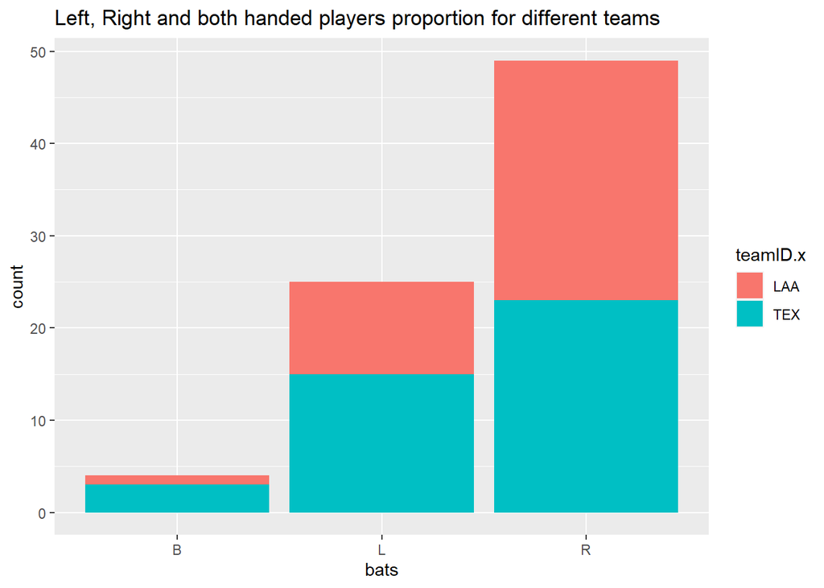

```r
ggplot(data = uni_sub, aes(x= bats, fill = teamID.x)) +geom_bar()+labs(title = "Left, Right and both handed players proportion for different teams")
```

..

we can see that in both team right handed players are the most in number. And TEX team has more both handed player than LAA team.

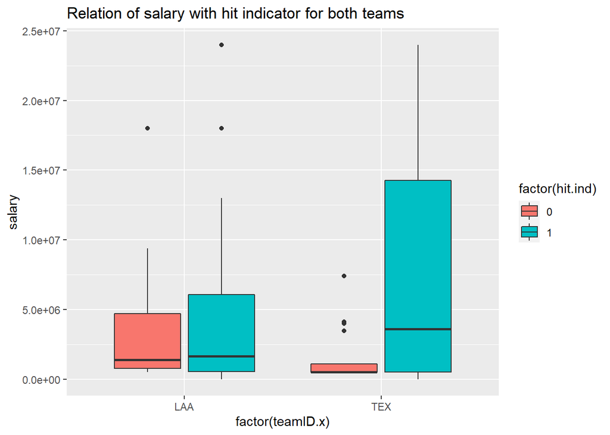

```r
#ggplot(data = uni_sub, aes(x= salary, col=teamID.x)+geom_bar()

ggplot(data = uni_sub, aes(x = factor(teamID.x), y = salary, fill = factor(hit.ind) )) + geom_boxplot()+labs(title = "Relation of salary with hit indicator for both teams")
```

..

we can see that for Both LAA and TEX player who have hit.ind = 1 have a higher salary.

## 2.3 Additional insights and issues

- We found heteroskadacity between career length and salary. This phenomenong might be happens between two other varialbes.
- We found linear relationship between career length and age. IF both of them are in dependant variable there is multicollinarity issue. Their might be other multicollinarity between AB and runs. Beacuse the player good at runs, good chance that they are good at At bats. There might be more.
- we will may do regression with interaction to detect the multicollinarity. Or steps function will automatically delete them to find the most optimized model.

# 3. Modelling

## 3.1 Build a model for player salary

##### Analysis Plan

- we wont add birthdate in our model as it is represented on Age column
- Player ID have no impact on player salary. so no need to add it in our model.
- From EDA we found that there is multicolinarity between players age and experiecne. SO we will not use both of them for our anlysis. We will only use Experiece rather than age.
- we also saw that there is no difference between players salary based on their team. so we also wont use the team ID for players salary.
- Here we have both categorical and numerical value in our independent variable. So we will use ancova for developing our model.

##### Execution of plan

Lets build our first model including all the variables.

```r
model1<-lm(uni_sub$salary~uni_sub$G+uni_sub$R+uni_sub$H+uni_sub$AB+uni_sub$RBI+uni_sub$weight+uni_sub$height+uni_sub$career.length+uni_sub$bats+uni_sub$hit.ind)
summary(model1)
```

```
##
## Call:
## lm(formula = uni_sub$salary ~ uni_sub$G + uni_sub$R + uni_sub$H +
##     uni_sub$AB + uni_sub$RBI + uni_sub$weight + uni_sub$height +
##     uni_sub$career.length + uni_sub$bats + uni_sub$hit.ind)
##
## Residuals:
##      Min       1Q   Median       3Q      Max
## -8211551 -2834565  -309335  1696655 12264305
##
## Coefficients:
##                        Estimate Std. Error t value Pr(>|t|)
## (Intercept)           -52995923   20199626  -2.624  0.01080 *
## uni_sub$G                -47400      35826  -1.323  0.19039
## uni_sub$R                 15442     107895   0.143  0.88663
## uni_sub$H                185812      99805   1.862  0.06709 .
## uni_sub$AB               -31297      26397  -1.186  0.24000
## uni_sub$RBI              -19112      91778  -0.208  0.83568
## uni_sub$weight           -16487      12841  -1.284  0.20365
## uni_sub$height           720650     271404   2.655  0.00992 **
## uni_sub$career.length   1044003     161013   6.484 1.33e-08 ***
## uni_sub$batsL           3500987    2724030   1.285  0.20321
## uni_sub$batsR           2707603    2614600   1.036  0.30418
## uni_sub$hit.ind          873580    1521255   0.574  0.56775
## ---
## Signif. codes:  0 '***' 0.001 '**' 0.01 '*' 0.05 '.' 0.1 ' ' 1
##
## Residual standard error: 4670000 on 66 degrees of freedom
## Multiple R-squared:  0.5448, Adjusted R-squared:  0.4689
## F-statistic:  7.18 on 11 and 66 DF,  p-value: 7.147e-08
```

- here we can see that all the variables are not significant. If we check for 95 percent confidence interval we can remove some of the variable as they donot contribute to our model
- Multiple R squared is 0.54. SO our model can expalin 54 percent of the data.

Now lets see if we remove G, R, AB, RBI, weight, bats, hit.ind what happened

```r
model2<-lm(uni_sub$salary~uni_sub$height+uni_sub$career.length+ uni_sub$H)
summary(model2)
```

```
##
## Call:
## lm(formula = uni_sub$salary ~ uni_sub$height + uni_sub$career.length +
##     uni_sub$H)
##
## Residuals:
##      Min       1Q   Median       3Q      Max
## -8747464 -2626649  -600012  1930658 14846376
##
## Coefficients:
##                        Estimate Std. Error t value Pr(>|t|)
## (Intercept)           -54348788   18316395  -2.967  0.00405 **
## uni_sub$height           714351     247651   2.885  0.00513 **
## uni_sub$career.length   1004128     152293   6.593 5.58e-09 ***
## uni_sub$H                 35389      10810   3.274  0.00161 **
## ---
## Signif. codes:  0 '***' 0.001 '**' 0.01 '*' 0.05 '.' 0.1 ' ' 1
##
## Residual standard error: 4673000 on 74 degrees of freedom
## Multiple R-squared:  0.4887, Adjusted R-squared:  0.468
## F-statistic: 23.58 on 3 and 74 DF,  p-value: 8.154e-11
```

Lets see what is the suggestion from the step function

```r
step.model = step(model1)
```

```
## Start:  AIC=2406.59
## uni_sub$salary ~ uni_sub$G + uni_sub$R + uni_sub$H + uni_sub$AB +
##     uni_sub$RBI + uni_sub$weight + uni_sub$height + uni_sub$career.length +
##     uni_sub$bats + uni_sub$hit.ind
##
##                         Df  Sum of Sq        RSS    AIC
## - uni_sub$bats           2 3.7214e+13 1.4763e+15 2404.6
## - uni_sub$R              1 4.4661e+11 1.4395e+15 2404.6
## - uni_sub$RBI            1 9.4555e+11 1.4400e+15 2404.7
## - uni_sub$hit.ind        1 7.1903e+12 1.4463e+15 2405.0
## - uni_sub$AB             1 3.0653e+13 1.4698e+15 2406.2
## - uni_sub$weight         1 3.5945e+13 1.4750e+15 2406.5
## <none>                                1.4391e+15 2406.6
## - uni_sub$G              1 3.8167e+13 1.4773e+15 2406.6
## - uni_sub$H              1 7.5577e+13 1.5147e+15 2408.6
## - uni_sub$height         1 1.5373e+14 1.5928e+15 2412.5
## - uni_sub$career.length  1 9.1670e+14 2.3558e+15 2443.0
##
## Step:  AIC=2404.59
## uni_sub$salary ~ uni_sub$G + uni_sub$R + uni_sub$H + uni_sub$AB +
##     uni_sub$RBI + uni_sub$weight + uni_sub$height + uni_sub$career.length +
##     uni_sub$hit.ind
##
##                         Df  Sum of Sq        RSS    AIC
## - uni_sub$R              1 2.9128e+08 1.4763e+15 2402.6
## - uni_sub$RBI            1 1.2824e+12 1.4776e+15 2402.7
## - uni_sub$hit.ind        1 1.1814e+13 1.4881e+15 2403.2
## - uni_sub$G              1 3.0137e+13 1.5065e+15 2404.2
## <none>                                1.4763e+15 2404.6
## - uni_sub$AB             1 3.8533e+13 1.5148e+15 2404.6
## - uni_sub$weight         1 4.8639e+13 1.5250e+15 2405.1
## - uni_sub$H              1 7.2886e+13 1.5492e+15 2406.3
## - uni_sub$height         1 1.6328e+14 1.6396e+15 2410.8
## - uni_sub$career.length  1 8.8402e+14 2.3603e+15 2439.2
##
## Step:  AIC=2402.59
## uni_sub$salary ~ uni_sub$G + uni_sub$H + uni_sub$AB + uni_sub$RBI +
##     uni_sub$weight + uni_sub$height + uni_sub$career.length +
##     uni_sub$hit.ind
##
```

[output cut: 44 more lines]

```
## <none>                                1.5158e+15 2398.6
## - uni_sub$G              1 6.9361e+13 1.5851e+15 2400.1
## - uni_sub$height         1 1.6862e+14 1.6844e+15 2404.9
## - uni_sub$H              1 1.9341e+14 1.7092e+15 2406.0
## - uni_sub$career.length  1 9.8871e+14 2.5045e+15 2435.8
##
## Step:  AIC=2398.3
## uni_sub$salary ~ uni_sub$G + uni_sub$H + uni_sub$height + uni_sub$career.length
##
##                         Df  Sum of Sq        RSS    AIC
## <none>                                1.5482e+15 2398.3
## - uni_sub$G              1 6.7959e+13 1.6162e+15 2399.7
## - uni_sub$height         1 1.4920e+14 1.6974e+15 2403.5
## - uni_sub$H              1 1.8488e+14 1.7331e+15 2405.1
## - uni_sub$career.length  1 9.5654e+14 2.5048e+15 2433.8
```

```r
summary(step.model)
```

```
##
## Call:
## lm(formula = uni_sub$salary ~ uni_sub$G + uni_sub$H + uni_sub$height +
##     uni_sub$career.length)
##
## Residuals:
##      Min       1Q   Median       3Q      Max
## -8438944 -2957722  -332640  1832525 13926853
##
## Coefficients:
##                        Estimate Std. Error t value Pr(>|t|)
## (Intercept)           -48199190   18373563  -2.623  0.01060 *
## uni_sub$G                -57107      31902  -1.790  0.07759 .
## uni_sub$H                 79964      27084   2.952  0.00424 **
## uni_sub$height           653529     246397   2.652  0.00980 **
## uni_sub$career.length   1007965     150089   6.716 3.49e-09 ***
## ---
## Signif. codes:  0 '***' 0.001 '**' 0.01 '*' 0.05 '.' 0.1 ' ' 1
##
## Residual standard error: 4605000 on 73 degrees of freedom
## Multiple R-squared:  0.5102, Adjusted R-squared:  0.4834
## F-statistic: 19.01 on 4 and 73 DF,  p-value: 9.496e-11
```

we can see the best model for salary is lm(formula = salary ~ G + H + height + career.length) It has the minimum AIC, and as multiple R squared is 0.51 the model can describe 51 percent of the variables. And the F statistics are really significant.

## 3.2 Critique model using relevant diagnostics

Lets look at the resudual, qqplots of model 1. The model that includes maximum number of variables

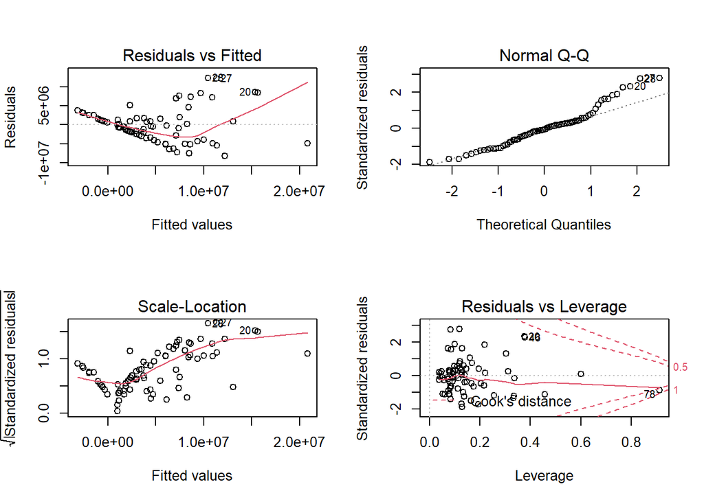

```r
par(mfrow = c(2, 2))
plot(model1)
```

.. we can see anomalies in residual plot. qqplot doesnot follow the referece (dotted line) line.

lets plot model2

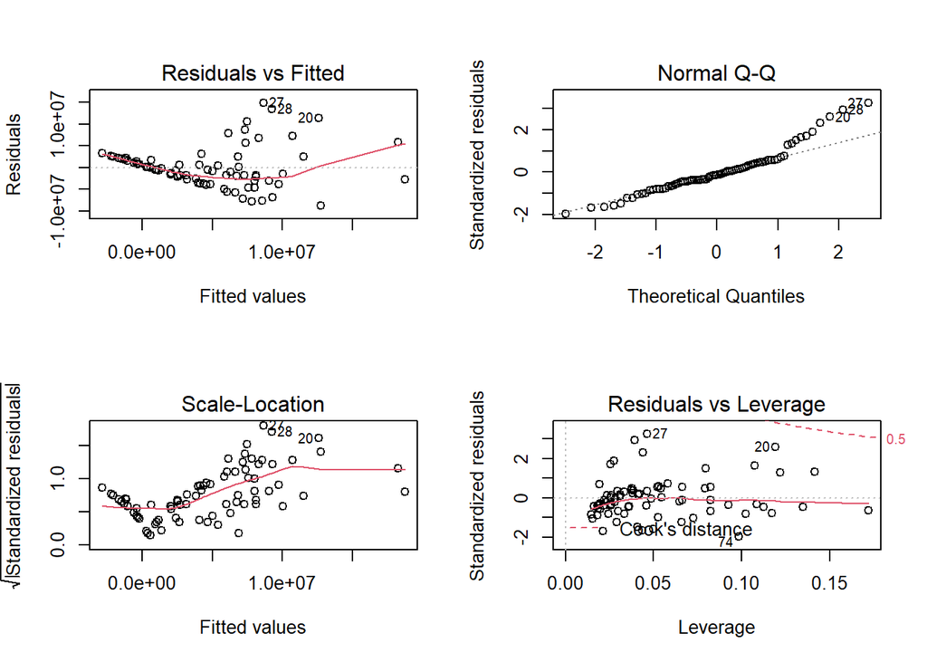

```r
par(mfrow = c(2, 2))
plot(model2)
```

.. we see a little progress in our plot. But the progress is not significant. As outliers distort the model

Now lets plot the model generated by step funciton.

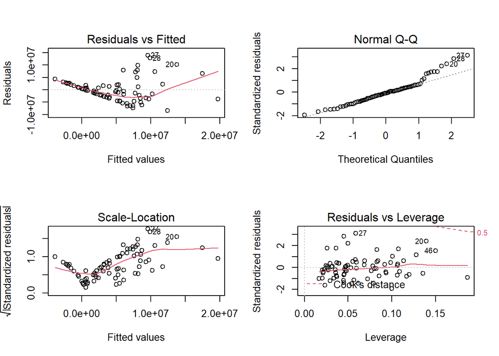

```r
par(mfrow = c(2, 2))
plot(step.model)
```

..

we see still there is not that much progress. And step function doesnot perform well interms of residulas. so there might be some problem with the dependant variable. Which we will inspect in section 3.3

## 3.3 Suggest improvements to your model

lets plot the salary. May be there are some outliers

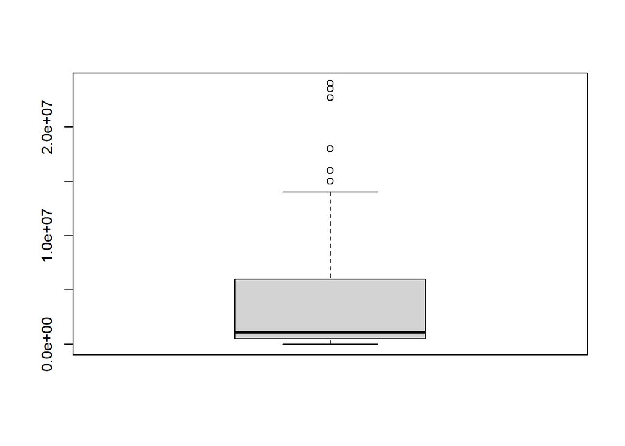

```r
boxplot(uni_sub$salary)
```

..

we see there are lot of outliers here. One option is to try a transformation. Square root and log transformations both pull in high numbers. This can make assumptions work better if the outlier is a dependent variable and can reduce the impact of a single point if the outlier is an independent variable. [1][2]

From this reference [3] we can see a way to deal with heteroskadacity is to trasform the dependant variable. lets do it

Now lets update our model

```r
model3<-lm(I(sqrt(uni_sub$salary))~uni_sub$height+uni_sub$career.length)
summary(model3)
```

```
##
## Call:
## lm(formula = I(sqrt(uni_sub$salary)) ~ uni_sub$height + uni_sub$career.length)
##
## Residuals:
##      Min       1Q   Median       3Q      Max
## -2173.03  -504.22    -5.04   385.07  2392.39
##
## Coefficients:
##                       Estimate Std. Error t value Pr(>|t|)
## (Intercept)           -7297.59    3506.17  -2.081   0.0408 *
## uni_sub$height          105.55      47.53   2.221   0.0294 *
## uni_sub$career.length   241.87      29.94   8.079 8.46e-12 ***
## ---
## Signif. codes:  0 '***' 0.001 '**' 0.01 '*' 0.05 '.' 0.1 ' ' 1
##
## Residual standard error: 948 on 75 degrees of freedom
## Multiple R-squared:  0.4745, Adjusted R-squared:  0.4605
## F-statistic: 33.86 on 2 and 75 DF,  p-value: 3.319e-11
```

We can see all the varialbes are significant and R squared is satisfactory. Lets plot the model to see if the anomaly removed.

```
## Error: $ operator is invalid for atomic vectors
```

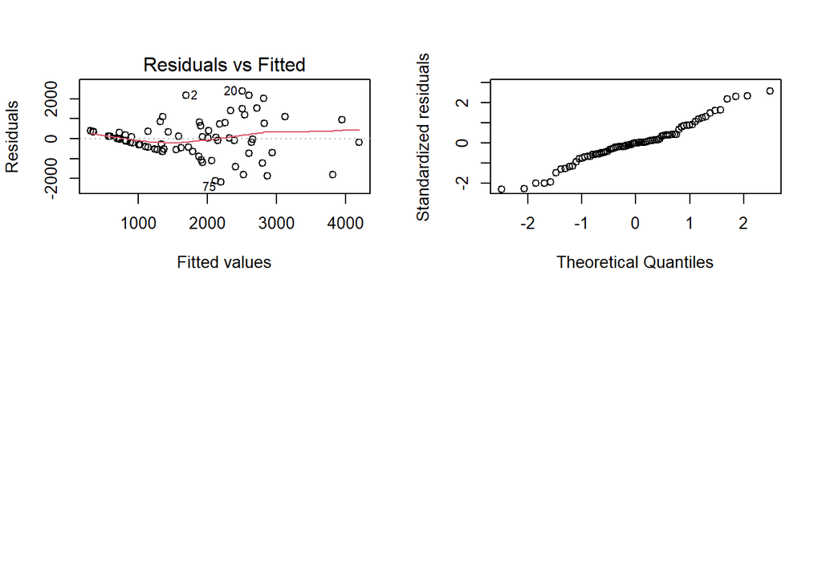

```r
par(mfrow = c(2, 2))
plot(model3)
```

..

The error for ploting generated from I function [4]. But still with the plot we can see that our model interms of residual performs better than the previous one.

# 4. Extension work

## 4.1 Model the likelihood of a player having scored a Hit (using the hit.ind variable provided).

##### Plan

- here the output variable hit.ind is a binary categorical variable. So I will use Logistic Regression
- We will investigate odd ratio to see which variable has how much effect

```r
uni_sub$hit.ind <- as.factor(uni_sub$hit.ind)

typeof(uni_sub$hit.ind)
```

```
## [1] "integer"
```

```r
hit.ind.glm<-glm(hit.ind~G+R+AB+RBI+height+career.length+salary ,data = uni_sub, family = "binomial")
summary(hit.ind.glm)
```

```
##
## Call:
## glm(formula = hit.ind ~ G + R + AB + RBI + height + career.length +
##     salary, family = "binomial", data = uni_sub)
##
## Deviance Residuals:
##     Min       1Q   Median       3Q      Max
## -1.4024  -0.1078   0.0000   0.0000   2.4886
##
## Coefficients:
##                 Estimate Std. Error z value Pr(>|z|)
## (Intercept)    3.043e+01  3.000e+01   1.014   0.3104
## G              7.775e-03  4.566e-02   0.170   0.8648
## R             -3.016e-01  1.655e+00  -0.182   0.8554
## AB             1.209e+00  5.999e-01   2.016   0.0438 *
## RBI           -3.559e+00  1.435e+03  -0.002   0.9980
## height        -5.076e-01  4.224e-01  -1.202   0.2294
## career.length  4.462e-01  2.510e-01   1.777   0.0755 .
## salary         7.400e-08  1.423e-07   0.520   0.6032
## ---
## Signif. codes:  0 '***' 0.001 '**' 0.01 '*' 0.05 '.' 0.1 ' ' 1
##
## (Dispersion parameter for binomial family taken to be 1)
##
##     Null deviance: 105.604  on 77  degrees of freedom
## Residual deviance:  12.121  on 70  degrees of freedom
## AIC: 28.121
##
## Number of Fisher Scoring iterations: 25
```

Our algorithm is may be facing overfitting problem. [5] Lets see if there is any mulitcollinarity between the variables. I want to recall our step funciton for previous salary estimation model

##### slaray ~ G + H + height + career.length

here it removed all the R, AB, RBI there might be multicollinarity between them.

Lets plot them in pairs

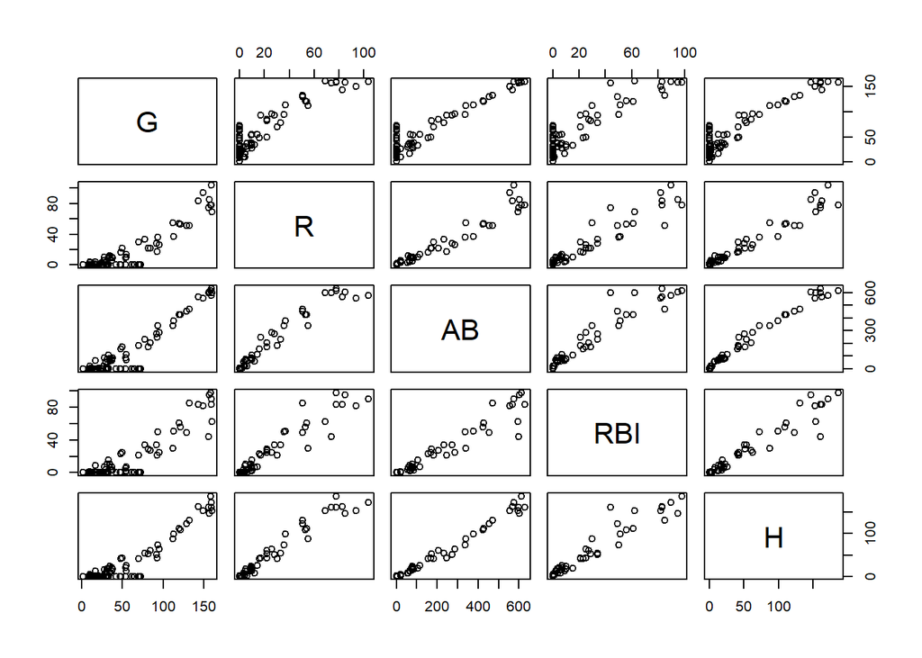

```r
plt<-subset(uni_sub, select=c("G", "R", "AB", "RBI", "H") )
pairs(plt)
```

..

We can see there is strong correlation between all of them.

As suggested from this paper [6] we will remove linearly related variables. Now lets see whats happens

```r
hit.ind.glm2<-glm(hit.ind~G+height+career.length+salary ,data = uni_sub, family = "binomial")

summary(hit.ind.glm2)
```

```
##
## Call:
## glm(formula = hit.ind ~ G + height + career.length + salary,
##     family = "binomial", data = uni_sub)
##
## Deviance Residuals:
##     Min       1Q   Median       3Q      Max
## -2.2038  -0.7941   0.1545   0.7302   2.0495
##
## Coefficients:
##                 Estimate Std. Error z value Pr(>|z|)
## (Intercept)    2.614e+01  1.180e+01   2.215  0.02676 *
## G              3.028e-02  1.044e-02   2.901  0.00372 **
## height        -3.838e-01  1.614e-01  -2.378  0.01738 *
## career.length  1.139e-01  1.082e-01   1.053  0.29225
## salary         1.207e-07  7.238e-08   1.668  0.09534 .
## ---
## Signif. codes:  0 '***' 0.001 '**' 0.01 '*' 0.05 '.' 0.1 ' ' 1
##
## (Dispersion parameter for binomial family taken to be 1)
##
##     Null deviance: 105.604  on 77  degrees of freedom
## Residual deviance:  71.162  on 73  degrees of freedom
## AIC: 81.162
##
## Number of Fisher Scoring iterations: 6
```

```r
hit.ind.glm3<-glm(hit.ind~G+height+salary ,data = uni_sub, family = "binomial")

summary(hit.ind.glm3)
```

```
##
## Call:
## glm(formula = hit.ind ~ G + height + salary, family = "binomial",
##     data = uni_sub)
##
## Deviance Residuals:
##     Min       1Q   Median       3Q      Max
## -2.0350  -0.7988   0.1421   0.6904   1.9934
##
## Coefficients:
##               Estimate Std. Error z value Pr(>|z|)
## (Intercept)  2.679e+01  1.159e+01   2.312  0.02080 *
## G            3.067e-02  1.044e-02   2.937  0.00332 **
## height      -3.870e-01  1.583e-01  -2.444  0.01452 *
## salary       1.575e-07  6.606e-08   2.384  0.01712 *
## ---
## Signif. codes:  0 '***' 0.001 '**' 0.01 '*' 0.05 '.' 0.1 ' ' 1
##
## (Dispersion parameter for binomial family taken to be 1)
##
##     Null deviance: 105.604  on 77  degrees of freedom
## Residual deviance:  72.293  on 74  degrees of freedom
## AIC: 80.293
##
## Number of Fisher Scoring iterations: 6
```

we see all the variables are significant here and AIC is also decreased.

##### Let’s see what step function brings to us

```r
step.model.glm <- step(hit.ind.glm)
```

```
## Start:  AIC=28.12
## hit.ind ~ G + R + AB + RBI + height + career.length + salary
```

```
##                 Df Deviance    AIC
## - RBI            1    12.12  26.12
## - G              1    12.15  26.15
## - R              1    12.16  26.16
## - height         1    13.71  27.71
## <none>                12.12  28.12
## - career.length  1    16.33  30.33
## - AB             1    19.37  33.37
## - salary         1   720.87 734.87
```

```
##
## Step:  AIC=26.12
## hit.ind ~ G + R + AB + height + career.length + salary
```

```
##                 Df Deviance    AIC
## - G              1   12.149 24.149
## - R              1   12.155 24.155
## - salary         1   12.398 24.398
## - height         1   13.710 25.709
## <none>               12.120 26.120
## - career.length  1   16.328 28.328
## - AB             1   19.568 31.568
```

```
##
## Step:  AIC=24.15
## hit.ind ~ R + AB + height + career.length + salary
```

```
##                 Df Deviance    AIC
## - R              1   12.195 22.195
## - salary         1   12.403 22.403
## - height         1   13.722 23.722
## <none>               12.149 24.149
## - career.length  1   16.438 26.438
## - AB             1   19.596 29.596
```

```
##
## Step:  AIC=22.2
## hit.ind ~ AB + height + career.length + salary
```

```
##                 Df Deviance    AIC
## - salary         1   12.569 20.569
## - height         1   13.751 21.751
## <none>               12.196 22.196
## - career.length  1   16.630 24.630
## - AB             1   82.940 90.940
```

```
##
## Step:  AIC=20.57
## hit.ind ~ AB + height + career.length
```

```
##                 Df Deviance    AIC
## - height         1   13.803 19.803
## <none>               12.569 20.569
## - career.length  1   18.399 24.399
## - AB             1   86.873 92.873
```

```
##
## Step:  AIC=19.8
## hit.ind ~ AB + career.length
```

```
##                 Df Deviance     AIC
## <none>               13.803  19.803
## - career.length  1   18.492  22.492
## - AB             1   97.388 101.388
```

```r
summary(step.model.glm)
```

```
##
## Call:
## glm(formula = hit.ind ~ AB + career.length, family = "binomial",
##     data = uni_sub)
##
## Deviance Residuals:
##     Min       1Q   Median       3Q      Max
## -1.7996  -0.1306   0.0000   0.0000   2.2014
##
## Coefficients:
##               Estimate Std. Error z value Pr(>|z|)
## (Intercept)    -6.0483     2.1744  -2.782  0.00541 **
## AB              1.1689     0.4523   2.584  0.00975 **
## career.length   0.4006     0.2183   1.835  0.06644 .
## ---
## Signif. codes:  0 '***' 0.001 '**' 0.01 '*' 0.05 '.' 0.1 ' ' 1
##
## (Dispersion parameter for binomial family taken to be 1)
##
##     Null deviance: 105.604  on 77  degrees of freedom
## Residual deviance:  13.803  on 75  degrees of freedom
## AIC: 19.803
##
## Number of Fisher Scoring iterations: 14
```

we see the model suggested by step function is hit.ind~ AB + career.length

Lets see the odd ratio so that we make some precise decisions

```r
exp(coef(step.model.glm))
```

```
##   (Intercept)            AB career.length
##   0.002361757   3.218609113   1.492737170
```

we can see that At Bats score and career length increase the chance for making a hit in 2015 match.

# References

1. https://www.theanalysisfactor.com/outliers-to-drop-or-not-to-drop/#:~:text=You%20may%20run%20the%20analysis,any%20significance%20from%20your%20analysis.
2. https://cooldata.wordpress.com/2010/03/04/why-transform-the-dependent-variable/
3. https://statisticsbyjim.com/regression/heteroscedasticity-regression/
4. https://stackoverflow.com/questions/40572124/plot-lm-error-operator-is-invalid-for-atomic-vectors
5. https://www.researchgate.net/post/Help_with_Logistic_Regression_In_rglmfit_fitted_probabilities_numerically_0_or_1_occurred_glmfit_algorithm_did_not_converge
6. Senaviratna, N.A.M.R. and Cooray, T.M.J.A., 2019. Diagnosing Multicollinearity of Logistic Regression Model. Asian Journal of Probability and Statistics, pp.1-9.